# ANCOVA in flow (math) (flow (math))

Geiser C. Challco geiser@alumni.usp.br

- Setting Initial Variables
- Descriptive Statistics of Initial Data
- ANCOVA and Pairwise for one factor: **grupo**
  - Without remove non-normal data
  - Computing ANCOVA and PairWise After removing non-normal data (OK)
    - Plots for ancova
    - Checking linearity assumption
    - Checking normality and homogeneity
- ANCOVA and Pairwise for two factors **grupo:Sexo**
  - Without remove non-normal data
  - Computing ANCOVA and PairWise After removing non-normal data (OK)
    - Plots for ancova
    - Checking linearity assumption
    - Checking normality and homogeneity
- ANCOVA and Pairwise for two factors **grupo:Zona**
  - Without remove non-normal data
  - Computing ANCOVA and PairWise After removing non-normal data (OK)
    - Plots for ancova
    - Checking linearity assumption
    - Checking normality and homogeneity
- ANCOVA and Pairwise for two factors **grupo:Cor.Raca**
  - Without remove non-normal data
  - Computing ANCOVA and PairWise After removing non-normal data (OK)
    - Plots for ancova
    - Checking linearity assumption
    - Checking normality and homogeneity
- ANCOVA and Pairwise for two factors **grupo:Serie**
  - Without remove non-normal data
  - Computing ANCOVA and PairWise After removing non-normal data (OK)
    - Plots for ancova
    - Checking linearity assumption
    - Checking normality and homogeneity
- Summary of Results
  - Descriptive Statistics
  - ANCOVA Table Comparison
  - PairWise Table Comparison
  - EMMS Table Comparison

**NOTE**:

- Teste ANCOVA para determinar se houve diferenças significativas no flow (math) (medido usando pre- e pos-testes).
- ANCOVA test to determine whether there were significant differences in flow (math) (measured using pre- and post-tests).

# Setting Initial Variables

```r
dv = "flow.math"
dv.pos = "fss.media.math"
dv.pre = "dfs.media.math"

fatores2 <- c("Sexo","Zona","Cor.Raca","Serie")
lfatores2 <- as.list(fatores2)
names(lfatores2) <- fatores2

fatores1 <- c("grupo", fatores2)
lfatores1 <- as.list(fatores1)
names(lfatores1) <- fatores1

lfatores <- c(lfatores1)

color <- list()
color[["prepost"]] = c("#ffee65","#f28e2B")
color[["grupo"]] = c("#bcbd22","#fd7f6f")
color[["Sexo"]] = c("#FF007F","#4D4DFF")
color[["Zona"]] = c("#AA00FF","#00CCCC")
color[["Cor.Raca"]] = c(
  "Parda"="#b97100","Indígena"="#9F262F",
  "Branca"="#87c498", "Preta"="#848283","Amarela"="#D6B91C"
)

level <- list()
level[["grupo"]] = c("Controle","Experimental")
level[["Sexo"]] = c("F","M")
level[["Zona"]] = c("Rural","Urbana")
level[["Cor.Raca"]] = c("Parda","Indígena","Branca", "Preta","Amarela")
level[["Serie"]] = c("6 ano","7 ano","8 ano","9 ano")

# ..

ymin <- 0
ymax <- 0

ymin.ci <- 0
ymax.ci <- 0


color[["grupo:Sexo"]] = c(
  "Controle:F"="#ff99cb", "Controle:M"="#b7b7ff",
  "Experimental:F"="#FF007F", "Experimental:M"="#4D4DFF",
  "Controle.F"="#ff99cb", "Controle.M"="#b7b7ff",
  "Experimental.F"="#FF007F", "Experimental.M"="#4D4DFF"
)
color[["grupo:Zona"]] = c(
  "Controle:Rural"="#b2efef","Controle:Urbana"="#e5b2ff",
  "Experimental:Rural"="#00CCCC", "Experimental:Urbana"="#AA00FF",
  "Controle.Rural"="#b2efef","Controle.Urbana"="#e5b2ff",
  "Experimental.Rural"="#00CCCC", "Experimental.Urbana"="#AA00FF"
)
color[["grupo:Cor.Raca"]] = c(
    "Controle:Parda"="#e3c699", "Experimental:Parda"="#b97100",
    "Controle:Indígena"="#e2bdc0", "Experimental:Indígena"="#9F262F",
    "Controle:Branca"="#c0e8cb", "Experimental:Branca"="#87c498",
    "Controle:Preta"="#dad9d9", "Experimental:Preta"="#848283",
    "Controle:Amarela"="#eee3a4", "Experimental:Amarela"="#D6B91C",

    "Controle.Parda"="#e3c699", "Experimental.Parda"="#b97100",
    "Controle.Indígena"="#e2bdc0", "Experimental.Indígena"="#9F262F",
    "Controle.Branca"="#c0e8cb", "Experimental.Branca"="#87c498",
    "Controle.Preta"="#dad9d9", "Experimental.Preta"="#848283",
    "Controle.Amarela"="#eee3a4", "Experimental.Amarela"="#D6B91C"
)


for (coln in c("vocab","vocab.teach","vocab.non.teach","score.tde",
               "TFL.lidas.per.min","TFL.corretas.per.min","TFL.erradas.per.min","TFL.omitidas.per.min",
               "leitura.compreensao")) {
  color[[paste0(coln,".quintile")]] = c("#BF0040","#FF0000","#800080","#0000FF","#4000BF")
  level[[paste0(coln,".quintile")]] = c("1st quintile","2nd quintile","3rd quintile","4th quintile","5th quintile")
  color[[paste0("grupo:",coln,".quintile")]] = c(
    "Experimental.1st quintile"="#BF0040", "Controle.1st quintile"="#d8668c",
    "Experimental.2nd quintile"="#FF0000", "Controle.2nd quintile"="#ff7f7f",
    "Experimental.3rd quintile"="#8fce00", "Controle.3rd quintile"="#ddf0b2",
    "Experimental.4th quintile"="#0000FF", "Controle.4th quintile"="#b2b2ff",
    "Experimental.5th quintile"="#4000BF", "Controle.5th quintile"="#b299e5",

    "Experimental:1st quintile"="#BF0040", "Controle:1st quintile"="#d8668c",
    "Experimental:2nd quintile"="#FF0000", "Controle:2nd quintile"="#ff7f7f",
    "Experimental:3rd quintile"="#8fce00", "Controle:3rd quintile"="#ddf0b2",
    "Experimental:4th quintile"="#0000FF", "Controle:4th quintile"="#b2b2ff",
    "Experimental:5th quintile"="#4000BF", "Controle:5th quintile"="#b299e5")
}


gdat <- read_excel("../data/data.xlsx", sheet = "sumary")
gdat <- gdat[which(is.na(gdat$Necessidade.Deficiencia) & !is.na(gdat$Stari.Grupo)),]



dat <- gdat
dat$grupo <- factor(dat[["Stari.Grupo"]], level[["grupo"]])
for (coln in c(names(lfatores))) {
  dat[[coln]] <- factor(dat[[coln]], level[[coln]][level[[coln]] %in% unique(dat[[coln]])])
}
dat <- dat[which(!is.na(dat[[dv.pre]]) & !is.na(dat[[dv.pos]])),]
dat <- dat[,c("id",names(lfatores),dv.pre,dv.pos)]

dat.long <- rbind(dat, dat)
dat.long$time <- c(rep("pre", nrow(dat)), rep("pos", nrow(dat)))
dat.long$time <- factor(dat.long$time, c("pre","pos"))
dat.long[[dv]] <- c(dat[[dv.pre]], dat[[dv.pos]])


for (f in c("grupo", names(lfatores))) {
  if (is.null(color[[f]]) && length(unique(dat[[f]])) > 0)
      color[[f]] <- distinctColorPalette(length(unique(dat[[f]])))
}
for (f in c(fatores2)) {
  if (is.null(color[[paste0("grupo:",f)]]) && length(unique(dat[[f]])) > 0)
    color[[paste0("grupo:",f)]] <- distinctColorPalette(length(unique(dat[["grupo"]]))*length(unique(dat[[f]])))
}

ldat <- list()
laov <- list()
lpwc <- list()
lemms <- list()
```

# Descriptive Statistics of Initial Data

```r
df <- get.descriptives(dat, c(dv.pre, dv.pos), c("grupo"),
                       include.global = T, symmetry.test = T, normality.test = F)
df <- plyr::rbind.fill(
  df, do.call(plyr::rbind.fill, lapply(lfatores2, FUN = function(f) {
    if (nrow(dat) > 0 && sum(!is.na(unique(dat[[f]]))) > 1)
      get.descriptives(dat, c(dv.pre,dv.pos), c("grupo", f),
                       symmetry.test = T, normality.test = F)
    }))
)
df <- df[,c(fatores1[fatores1 %in% colnames(df)],"variable",
            colnames(df)[!colnames(df) %in% c(fatores1,"variable")])]
```

| grupo | Sexo | Zona | Cor.Raca | Serie | variable | n | mean | median | min | max | sd | se | ci | iqr | symmetry | skewness | kurtosis |
| --- | --- | --- | --- | --- | --- | --- | --- | --- | --- | --- | --- | --- | --- | --- | --- | --- | --- |
| Controle |  |  |  |  | dfs.media.math | 99 | 3.290 | 3.222 | 2.333 | 4.444 | 0.487 | 0.049 | 0.097 | 0.556 | YES | 0.309 | -0.323 |
| Experimental |  |  |  |  | dfs.media.math | 46 | 3.271 | 3.278 | 1.889 | 4.556 | 0.604 | 0.089 | 0.179 | 0.889 | YES | -0.118 | -0.567 |
|  |  |  |  |  | dfs.media.math | 145 | 3.284 | 3.222 | 1.889 | 4.556 | 0.525 | 0.044 | 0.086 | 0.778 | YES | 0.100 | -0.276 |
| Controle |  |  |  |  | fss.media.math | 99 | 3.426 | 3.444 | 2.444 | 5.000 | 0.546 | 0.055 | 0.109 | 0.764 | NO | 0.577 | 0.193 |
| Experimental |  |  |  |  | fss.media.math | 46 | 3.284 | 3.333 | 2.000 | 4.556 | 0.674 | 0.099 | 0.200 | 0.861 | YES | 0.183 | -0.872 |
|  |  |  |  |  | fss.media.math | 145 | 3.381 | 3.333 | 2.000 | 5.000 | 0.591 | 0.049 | 0.097 | 0.750 | YES | 0.330 | -0.146 |
| Controle | F |  |  |  | dfs.media.math | 45 | 3.310 | 3.333 | 2.444 | 4.444 | 0.464 | 0.069 | 0.139 | 0.667 | YES | 0.293 | -0.617 |
| Controle | M |  |  |  | dfs.media.math | 54 | 3.273 | 3.222 | 2.333 | 4.444 | 0.509 | 0.069 | 0.139 | 0.556 | YES | 0.328 | -0.260 |
| Experimental | F |  |  |  | dfs.media.math | 17 | 3.046 | 3.000 | 1.889 | 4.556 | 0.688 | 0.167 | 0.354 | 0.667 | YES | 0.455 | -0.463 |
| Experimental | M |  |  |  | dfs.media.math | 29 | 3.402 | 3.444 | 2.222 | 4.333 | 0.517 | 0.096 | 0.197 | 0.667 | YES | -0.360 | -0.523 |
| Controle | F |  |  |  | fss.media.math | 45 | 3.389 | 3.333 | 2.444 | 4.556 | 0.507 | 0.076 | 0.152 | 0.667 | YES | 0.401 | -0.472 |
| Controle | M |  |  |  | fss.media.math | 54 | 3.456 | 3.444 | 2.444 | 5.000 | 0.580 | 0.079 | 0.158 | 0.771 | NO | 0.625 | 0.273 |
| Experimental | F |  |  |  | fss.media.math | 17 | 3.218 | 3.333 | 2.000 | 4.556 | 0.777 | 0.188 | 0.399 | 1.000 | YES | 0.157 | -1.234 |
| Experimental | M |  |  |  | fss.media.math | 29 | 3.323 | 3.333 | 2.222 | 4.556 | 0.617 | 0.115 | 0.235 | 0.889 | YES | 0.295 | -0.878 |
| Controle |  | Rural |  |  | dfs.media.math | 54 | 3.274 | 3.111 | 2.333 | 4.444 | 0.553 | 0.075 | 0.151 | 0.719 | YES | 0.404 | -0.685 |
| Controle |  | Urbana |  |  | dfs.media.math | 17 | 3.222 | 3.222 | 2.333 | 4.000 | 0.480 | 0.116 | 0.247 | 0.667 | YES | -0.031 | -1.067 |
| Controle |  |  |  |  | dfs.media.math | 28 | 3.361 | 3.333 | 2.667 | 4.222 | 0.340 | 0.064 | 0.132 | 0.444 | NO | 0.667 | 0.374 |
| Experimental |  | Rural |  |  | dfs.media.math | 29 | 3.360 | 3.333 | 2.222 | 4.556 | 0.524 | 0.097 | 0.199 | 0.556 | YES | 0.262 | -0.189 |
| Experimental |  | Urbana |  |  | dfs.media.math | 8 | 2.819 | 2.667 | 1.889 | 4.111 | 0.732 | 0.259 | 0.612 | 0.694 | YES | 0.434 | -1.220 |
| Experimental |  |  |  |  | dfs.media.math | 9 | 3.383 | 3.667 | 2.444 | 4.111 | 0.614 | 0.205 | 0.472 | 1.111 | YES | -0.461 | -1.699 |
| Controle |  | Rural |  |  | fss.media.math | 54 | 3.406 | 3.444 | 2.444 | 4.667 | 0.528 | 0.072 | 0.144 | 0.556 | YES | 0.139 | -0.317 |
| Controle |  | Urbana |  |  | fss.media.math | 17 | 3.611 | 3.444 | 2.667 | 5.000 | 0.749 | 0.182 | 0.385 | 1.222 | NO | 0.645 | -1.076 |
| Controle |  |  |  |  | fss.media.math | 28 | 3.352 | 3.333 | 2.778 | 4.000 | 0.420 | 0.079 | 0.163 | 0.750 | YES | 0.220 | -1.413 |
| Experimental |  | Rural |  |  | fss.media.math | 29 | 3.280 | 3.333 | 2.000 | 4.556 | 0.653 | 0.121 | 0.248 | 0.778 | YES | 0.093 | -0.754 |
| Experimental |  | Urbana |  |  | fss.media.math | 8 | 3.184 | 2.889 | 2.444 | 4.333 | 0.735 | 0.260 | 0.615 | 0.840 | NO | 0.610 | -1.484 |
| Experimental |  |  |  |  | fss.media.math | 9 | 3.387 | 3.333 | 2.111 | 4.556 | 0.752 | 0.251 | 0.578 | 1.111 | YES | -0.059 | -1.213 |
| Controle |  |  | Parda |  | dfs.media.math | 46 | 3.346 | 3.333 | 2.333 | 4.444 | 0.552 | 0.081 | 0.164 | 0.750 | YES | 0.106 | -0.877 |
| Controle |  |  | Branca |  | dfs.media.math | 9 | 3.395 | 3.333 | 2.889 | 4.444 | 0.553 | 0.184 | 0.425 | 0.444 | NO | 0.749 | -1.034 |
| Controle |  |  | Preta |  | dfs.media.math | 1 | 2.889 | 2.889 | 2.889 | 2.889 |  |  |  | 0.000 | few data | 0.000 | 0.000 |
| Controle |  |  |  |  | dfs.media.math | 43 | 3.217 | 3.222 | 2.333 | 4.111 | 0.392 | 0.060 | 0.121 | 0.444 | YES | -0.020 | -0.194 |
| Experimental |  |  | Parda |  | dfs.media.math | 12 | 3.315 | 3.333 | 2.444 | 4.222 | 0.540 | 0.156 | 0.343 | 0.750 | YES | 0.097 | -1.312 |
| Experimental |  |  | Indígena |  | dfs.media.math | 5 | 3.422 | 3.556 | 2.667 | 4.111 | 0.552 | 0.247 | 0.686 | 0.556 | YES | -0.140 | -1.786 |
| Experimental |  |  | Branca |  | dfs.media.math | 6 | 3.093 | 3.333 | 2.222 | 3.667 | 0.568 | 0.232 | 0.596 | 0.667 | NO | -0.502 | -1.742 |
| Experimental |  |  | Amarela |  | dfs.media.math | 1 | 3.778 | 3.778 | 3.778 | 3.778 |  |  |  | 0.000 | few data | 0.000 | 0.000 |
| Experimental |  |  |  |  | dfs.media.math | 22 | 3.237 | 3.111 | 1.889 | 4.556 | 0.683 | 0.146 | 0.303 | 1.056 | YES | 0.004 | -0.728 |
| Controle |  |  | Parda |  | fss.media.math | 46 | 3.478 | 3.444 | 2.444 | 5.000 | 0.552 | 0.081 | 0.164 | 0.750 | YES | 0.321 | -0.031 |
| Controle |  |  | Branca |  | fss.media.math | 9 | 3.481 | 3.556 | 2.444 | 4.667 | 0.603 | 0.201 | 0.464 | 0.444 | YES | 0.254 | -0.347 |
| Controle |  |  | Preta |  | fss.media.math | 1 | 3.333 | 3.333 | 3.333 | 3.333 |  |  |  | 0.000 | few data | 0.000 | 0.000 |
| Controle |  |  |  |  | fss.media.math | 43 | 3.361 | 3.222 | 2.667 | 5.000 | 0.540 | 0.082 | 0.166 | 0.778 | NO | 0.899 | 0.451 |
| Experimental |  |  | Parda |  | fss.media.math | 12 | 3.259 | 3.278 | 2.111 | 4.333 | 0.589 | 0.170 | 0.374 | 0.722 | YES | -0.158 | -0.653 |
| Experimental |  |  | Indígena |  | fss.media.math | 5 | 3.778 | 4.111 | 2.556 | 4.556 | 0.793 | 0.355 | 0.985 | 0.778 | NO | -0.507 | -1.657 |
| Experimental |  |  | Branca |  | fss.media.math | 6 | 3.319 | 3.333 | 2.667 | 4.250 | 0.577 | 0.236 | 0.606 | 0.639 | YES | 0.332 | -1.468 |
| Experimental |  |  | Amarela |  | fss.media.math | 1 | 3.375 | 3.375 | 3.375 | 3.375 |  |  |  | 0.000 | few data | 0.000 | 0.000 |
| Experimental |  |  |  |  | fss.media.math | 22 | 3.172 | 3.111 | 2.000 | 4.556 | 0.721 | 0.154 | 0.320 | 0.722 | YES | 0.404 | -0.949 |
| Controle |  |  |  | 6 ano | dfs.media.math | 32 | 3.232 | 3.167 | 2.333 | 4.444 | 0.510 | 0.090 | 0.184 | 0.583 | NO | 0.542 | -0.503 |
| Controle |  |  |  | 7 ano | dfs.media.math | 31 | 3.336 | 3.333 | 2.444 | 4.222 | 0.482 | 0.087 | 0.177 | 0.646 | YES | -0.050 | -0.883 |
| Controle |  |  |  | 8 ano | dfs.media.math | 17 | 3.248 | 3.222 | 2.333 | 4.444 | 0.510 | 0.124 | 0.262 | 0.444 | YES | 0.431 | -0.031 |
| Controle |  |  |  | 9 ano | dfs.media.math | 19 | 3.351 | 3.333 | 2.444 | 4.444 | 0.459 | 0.105 | 0.221 | 0.444 | YES | 0.392 | 0.252 |
| Experimental |  |  |  | 6 ano | dfs.media.math | 15 | 3.526 | 3.556 | 2.556 | 4.556 | 0.581 | 0.150 | 0.322 | 0.778 | YES | 0.091 | -1.193 |
| Experimental |  |  |  | 7 ano | dfs.media.math | 11 | 3.303 | 3.333 | 2.556 | 4.222 | 0.533 | 0.161 | 0.358 | 0.833 | YES | 0.059 | -1.340 |
| Experimental |  |  |  | 8 ano | dfs.media.math | 11 | 3.000 | 3.111 | 1.889 | 4.111 | 0.648 | 0.195 | 0.435 | 0.722 | YES | -0.138 | -1.007 |
| Experimental |  |  |  | 9 ano | dfs.media.math | 9 | 3.136 | 3.222 | 2.222 | 3.778 | 0.582 | 0.194 | 0.447 | 1.000 | YES | -0.316 | -1.709 |
| Controle |  |  |  | 6 ano | fss.media.math | 32 | 3.452 | 3.444 | 2.444 | 5.000 | 0.585 | 0.103 | 0.211 | 0.604 | NO | 0.621 | -0.007 |
| Controle |  |  |  | 7 ano | fss.media.math | 31 | 3.480 | 3.444 | 2.444 | 5.000 | 0.582 | 0.104 | 0.213 | 0.778 | YES | 0.463 | 0.060 |
| Controle |  |  |  | 8 ano | fss.media.math | 17 | 3.291 | 3.111 | 2.444 | 4.556 | 0.551 | 0.134 | 0.283 | 0.667 | NO | 0.597 | -0.517 |
| Controle |  |  |  | 9 ano | fss.media.math | 19 | 3.414 | 3.333 | 2.778 | 4.333 | 0.421 | 0.097 | 0.203 | 0.556 | YES | 0.310 | -0.807 |
| Experimental |  |  |  | 6 ano | fss.media.math | 15 | 3.410 | 3.333 | 2.556 | 4.556 | 0.584 | 0.151 | 0.323 | 0.410 | NO | 0.663 | -0.723 |
| Experimental |  |  |  | 7 ano | fss.media.math | 11 | 3.538 | 3.556 | 2.000 | 4.333 | 0.736 | 0.222 | 0.494 | 0.833 | NO | -0.733 | -0.671 |
| Experimental |  |  |  | 8 ano | fss.media.math | 11 | 2.960 | 2.778 | 2.222 | 4.556 | 0.680 | 0.205 | 0.457 | 0.722 | NO | 1.074 | 0.066 |
| Experimental |  |  |  | 9 ano | fss.media.math | 9 | 3.160 | 3.222 | 2.111 | 4.111 | 0.648 | 0.216 | 0.498 | 0.667 | YES | 0.037 | -1.341 |

# ANCOVA and Pairwise for one factor: **grupo**

## Without remove non-normal data

```r
pdat = remove_group_data(dat[!is.na(dat[["grupo"]]),], "fss.media.math", "grupo")

pdat.long <- rbind(pdat[,c("id","grupo")], pdat[,c("id","grupo")])
pdat.long[["time"]] <- c(rep("pre", nrow(pdat)), rep("pos", nrow(pdat)))
pdat.long[["time"]] <- factor(pdat.long[["time"]], c("pre","pos"))
pdat.long[["flow.math"]] <- c(pdat[["dfs.media.math"]], pdat[["fss.media.math"]])

aov = anova_test(pdat, fss.media.math ~ dfs.media.math + grupo)
laov[["grupo"]] <- get_anova_table(aov)
```

```r
pwc <- emmeans_test(pdat, fss.media.math ~ grupo, covariate = dfs.media.math,
                    p.adjust.method = "bonferroni")
```

```r
pwc.long <- emmeans_test(dplyr::group_by_at(pdat.long, "grupo"),
                          flow.math ~ time,
                          p.adjust.method = "bonferroni")
lpwc[["grupo"]] <- plyr::rbind.fill(pwc, pwc.long)
```

```r
ds <- get.descriptives(pdat, "fss.media.math", "grupo", covar = "dfs.media.math")
ds <- merge(ds[ds$variable != "dfs.media.math",],
            ds[ds$variable == "dfs.media.math", !colnames(ds) %in% c("variable")],
            by = "grupo", all.x = T, suffixes = c("", ".dfs.media.math"))
ds <- merge(get_emmeans(pwc), ds, by = "grupo", suffixes = c(".emms", ""))
ds <- ds[,c("grupo","n","mean.dfs.media.math","se.dfs.media.math","mean","se",
            "emmean","se.emms","conf.low","conf.high")]

colnames(ds) <- c("grupo", "N", paste0(c("M","SE")," (pre)"),
                  paste0(c("M","SE"), " (unadj)"),
                  paste0(c("M", "SE"), " (adj)"), "conf.low", "conf.high")

lemms[["grupo"]] <- ds
```

## Computing ANCOVA and PairWise After removing non-normal data (OK)

```r
wdat = pdat

res = residuals(lm(fss.media.math ~ dfs.media.math + grupo, data = wdat))
non.normal = getNonNormal(res, wdat$id, plimit = 0.05)

wdat = wdat[!wdat$id %in% non.normal,]

wdat.long <- rbind(wdat[,c("id","grupo")], wdat[,c("id","grupo")])
wdat.long[["time"]] <- c(rep("pre", nrow(wdat)), rep("pos", nrow(wdat)))
wdat.long[["time"]] <- factor(wdat.long[["time"]], c("pre","pos"))
wdat.long[["flow.math"]] <- c(wdat[["dfs.media.math"]], wdat[["fss.media.math"]])

ldat[["grupo"]] = wdat

(non.normal)
```

```
##  [1] "P1768" "P3630" "P130"  "P3013" "P3014" "P2244" "P3508" "P1010" "P510"  "P3624" "P1089"
## [12] "P3598" "P1728" "P3160" "P3495" "P2247" "P3578" "P3094" "P622"  "P2294" "P3502" "P3031"
## [23] "P231"  "P1016" "P3055" "P2408" "P3116" "P2380" "P1705" "P3027" "P3244" "P3516" "P829"
## [34] "P3577" "P3511" "P1701" "P3002" "P458"  "P3566" "P2250" "P3153" "P2240" "P3239" "P612"
## [45] "P3519" "P1698" "P3721" "P2383" "P812"  "P523"  "P960"  "P2390" "P997"  "P3091" "P124"
## [56] "P613"  "P2378" "P820"  "P3560" "P133"  "P448"  "P184"  "P952"  "P3615" "P123"  "P238"
## [67] "P232"  "P3492" "P1091" "P2376" "P140"  "P121"  "P2222" "P3098" "P3022" "P1764" "P626"
## [78] "P1742" "P1101" "P457"  "P192"  "P1094" "P463"  "P3093" "P1711" "P3178" "P950"  "P3008"
## [89] "P947"  "P3512" "P138"  "P813"  "P3569" "P943"  "P3016" "P515"  "P3505" "P936"  "P3174"
```

```r
aov = anova_test(wdat, fss.media.math ~ dfs.media.math + grupo)
laov[["grupo"]] <- merge(get_anova_table(aov), laov[["grupo"]],
                            by="Effect", suffixes = c("","'"))

(df = get_anova_table(aov))
```

```
## ANOVA Table (type II tests)
##
##           Effect DFn DFd      F        p p<.05   ges
## 1 dfs.media.math   1  43 70.878 1.22e-10     * 0.622
## 2          grupo   1  43  4.567 3.80e-02     * 0.096
```

| Effect | DFn | DFd | F | p | p<.05 | ges |
| --- | --- | --- | --- | --- | --- | --- |
| dfs.media.math | 1 | 43 | 70.878 | 0.000 | * | 0.622 |
| grupo | 1 | 43 | 4.567 | 0.038 | * | 0.096 |

```r
pwc <- emmeans_test(wdat, fss.media.math ~ grupo, covariate = dfs.media.math,
                    p.adjust.method = "bonferroni")
```

| term | .y. | group1 | group2 | df | statistic | p | p.adj | p.adj.signif |
| --- | --- | --- | --- | --- | --- | --- | --- | --- |
| dfs.media.math*grupo | fss.media.math | Controle | Experimental | 43 | 2.137 | 0.038 | 0.038 | * |

```r
pwc.long <- emmeans_test(dplyr::group_by_at(wdat.long, "grupo"),
                         flow.math ~ time,
                         p.adjust.method = "bonferroni")
lpwc[["grupo"]] <- merge(plyr::rbind.fill(pwc, pwc.long), lpwc[["grupo"]],
                            by=c("grupo","term",".y.","group1","group2"),
                            suffixes = c("","'"))
```

| grupo | term | .y. | group1 | group2 | df | statistic | p | p.adj | p.adj.signif |
| --- | --- | --- | --- | --- | --- | --- | --- | --- | --- |
| Controle | time | flow.math | pre | pos | 88 | -5.554 | 0.000 | 0.000 | **** |
| Experimental | time | flow.math | pre | pos | 88 | -2.017 | 0.047 | 0.047 | * |

```r
ds <- get.descriptives(wdat, "fss.media.math", "grupo", covar = "dfs.media.math")
ds <- merge(ds[ds$variable != "dfs.media.math",],
            ds[ds$variable == "dfs.media.math", !colnames(ds) %in% c("variable")],
            by = "grupo", all.x = T, suffixes = c("", ".dfs.media.math"))
ds <- merge(get_emmeans(pwc), ds, by = "grupo", suffixes = c(".emms", ""))
ds <- ds[,c("grupo","n","mean.dfs.media.math","se.dfs.media.math","mean","se",
            "emmean","se.emms","conf.low","conf.high")]

colnames(ds) <- c("grupo", "N", paste0(c("M","SE")," (pre)"),
                  paste0(c("M","SE"), " (unadj)"),
                  paste0(c("M", "SE"), " (adj)"), "conf.low", "conf.high")

lemms[["grupo"]] <- merge(ds, lemms[["grupo"]], by=c("grupo"), suffixes = c("","'"))
```

| grupo | N | M (pre) | SE (pre) | M (unadj) | SE (unadj) | M (adj) | SE (adj) | conf.low | conf.high |
| --- | --- | --- | --- | --- | --- | --- | --- | --- | --- |
| Controle | 30 | 3.259 | 0.095 | 3.916 | 0.061 | 3.986 | 0.042 | 3.900 | 4.071 |
| Experimental | 16 | 3.632 | 0.140 | 3.958 | 0.105 | 3.827 | 0.059 | 3.708 | 3.946 |

### Plots for ancova

```r
plots <- oneWayAncovaPlots(
  wdat, "fss.media.math", "grupo", aov, list("grupo"=pwc), addParam = c("mean_ci"),
  font.label.size=10, step.increase=0.05, p.label="p.adj",
  subtitle = which(aov$Effect == "grupo"))
```

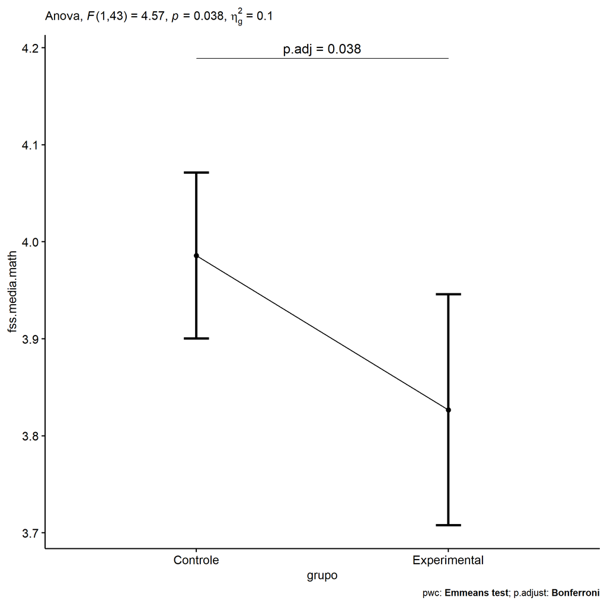

```r
if (!is.null(nrow(plots[["grupo"]]$data)))
  plots[["grupo"]] +
  if (ymin.ci < ymax.ci) ggplot2::ylim(ymin.ci, ymax.ci)
```

```r
plots <- oneWayAncovaBoxPlots(
  wdat, "fss.media.math", "grupo", aov, pwc, covar = "dfs.media.math",
  theme = "classic", color = color[["grupo"]],
  subtitle = which(aov$Effect == "grupo"))
```

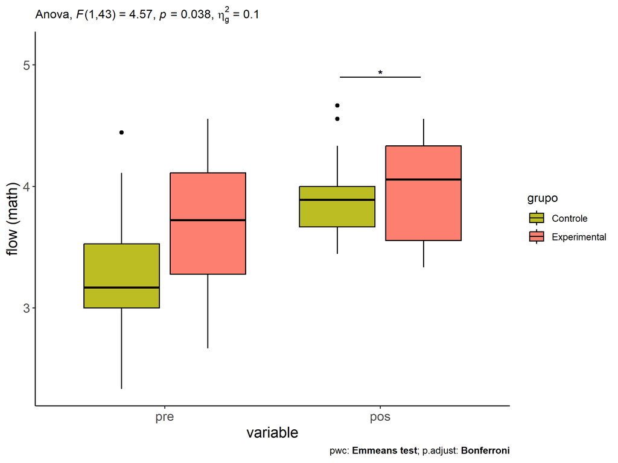

```r
if (length(unique(wdat[["grupo"]])) > 1)
  plots[["grupo"]] + ggplot2::ylab("flow (math)") +
  ggplot2::scale_x_discrete(labels=c('pre', 'pos')) +
  if (ymin < ymax) ggplot2::ylim(ymin, ymax)
```

```r
if (length(unique(wdat.long[["grupo"]])) > 1)
  plots <- oneWayAncovaBoxPlots(
    wdat.long, "flow.math", "grupo", aov, pwc.long,
    pre.post = "time", theme = "classic", color = color$prepost)
```

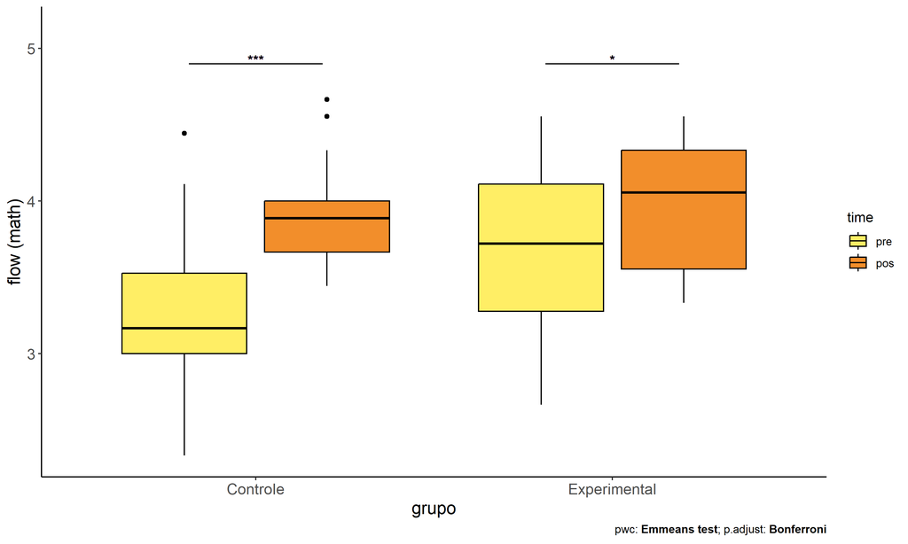

```r
if (length(unique(wdat.long[["grupo"]])) > 1)
  plots[["grupo"]] + ggplot2::ylab("flow (math)") +
  if (ymin < ymax) ggplot2::ylim(ymin, ymax)
```

### Checking linearity assumption

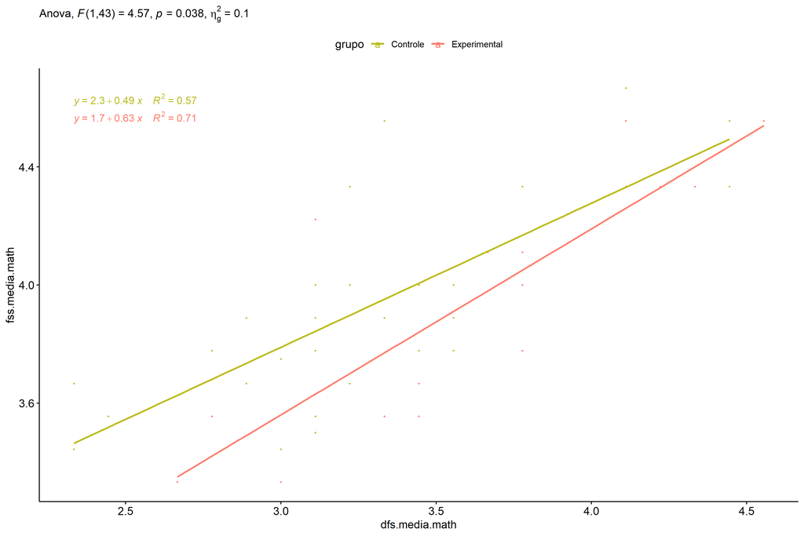

```r
ggscatter(wdat, x = "dfs.media.math", y = "fss.media.math", size = 0.5,
          color = "grupo", add = "reg.line")+
  stat_regline_equation(
    aes(label =  paste(..eq.label.., ..rr.label.., sep = "~~~~"), color = grupo)
  ) +
  ggplot2::labs(subtitle = rstatix::get_test_label(aov, detailed = T, row = which(aov$Effect == "grupo"))) +
  ggplot2::scale_color_manual(values = color[["grupo"]]) +
  if (ymin < ymax) ggplot2::ylim(ymin, ymax)
```

### Checking normality and homogeneity

```r
res <- augment(lm(fss.media.math ~ dfs.media.math + grupo, data = wdat))
```

```r
shapiro_test(res$.resid)
```

```
## # A tibble: 1 × 3
##   variable   statistic p.value
##   <chr>          <dbl>   <dbl>
## 1 res$.resid     0.948  0.0409
```

```r
levene_test(res, .resid ~ grupo)
```

```
## # A tibble: 1 × 4
##     df1   df2 statistic     p
##   <int> <int>     <dbl> <dbl>
## 1     1    44    0.0726 0.789
```

# ANCOVA and Pairwise for two factors **grupo:Sexo**

## Without remove non-normal data

```r
pdat = remove_group_data(dat[!is.na(dat[["grupo"]]) & !is.na(dat[["Sexo"]]),],
                         "fss.media.math", c("grupo","Sexo"))
pdat = pdat[pdat[["Sexo"]] %in% do.call(
  intersect, lapply(unique(pdat[["grupo"]]), FUN = function(x) {
    unique(pdat[["Sexo"]][which(pdat[["grupo"]] == x)])
  })),]
pdat[["grupo"]] = factor(pdat[["grupo"]], level[["grupo"]])
pdat[["Sexo"]] = factor(
  pdat[["Sexo"]],
  level[["Sexo"]][level[["Sexo"]] %in% unique(pdat[["Sexo"]])])

pdat.long <- rbind(pdat[,c("id","grupo","Sexo")], pdat[,c("id","grupo","Sexo")])
pdat.long[["time"]] <- c(rep("pre", nrow(pdat)), rep("pos", nrow(pdat)))
pdat.long[["time"]] <- factor(pdat.long[["time"]], c("pre","pos"))
pdat.long[["flow.math"]] <- c(pdat[["dfs.media.math"]], pdat[["fss.media.math"]])

if (length(unique(pdat[["Sexo"]])) >= 2) {
  aov = anova_test(pdat, fss.media.math ~ dfs.media.math + grupo*Sexo)
  laov[["grupo:Sexo"]] <- get_anova_table(aov)
}
```

```r
if (length(unique(pdat[["Sexo"]])) >= 2) {
  pwcs <- list()
  pwcs[["Sexo"]] <- emmeans_test(
    group_by(pdat, grupo), fss.media.math ~ Sexo,
    covariate = dfs.media.math, p.adjust.method = "bonferroni")
  pwcs[["grupo"]] <- emmeans_test(
    group_by(pdat, Sexo), fss.media.math ~ grupo,
    covariate = dfs.media.math, p.adjust.method = "bonferroni")

  pwc <- plyr::rbind.fill(pwcs[["grupo"]], pwcs[["Sexo"]])
  pwc <- pwc[,c("grupo","Sexo", colnames(pwc)[!colnames(pwc) %in% c("grupo","Sexo")])]
}
```

```r
if (length(unique(pdat[["Sexo"]])) >= 2) {
  pwc.long <- emmeans_test(dplyr::group_by_at(pdat.long, c("grupo","Sexo")),
                           flow.math ~ time,
                           p.adjust.method = "bonferroni")
  lpwc[["grupo:Sexo"]] <- plyr::rbind.fill(pwc, pwc.long)
}
```

```r
if (length(unique(pdat[["Sexo"]])) >= 2) {
  ds <- get.descriptives(pdat, "fss.media.math", c("grupo","Sexo"), covar = "dfs.media.math")
  ds <- merge(ds[ds$variable != "dfs.media.math",],
              ds[ds$variable == "dfs.media.math", !colnames(ds) %in% c("variable")],
              by = c("grupo","Sexo"), all.x = T, suffixes = c("", ".dfs.media.math"))
  ds <- merge(get_emmeans(pwcs[["grupo"]]), ds,
              by = c("grupo","Sexo"), suffixes = c(".emms", ""))
  ds <- ds[,c("grupo","Sexo","n","mean.dfs.media.math","se.dfs.media.math","mean","se",
              "emmean","se.emms","conf.low","conf.high")]

  colnames(ds) <- c("grupo","Sexo", "N", paste0(c("M","SE")," (pre)"),
                    paste0(c("M","SE"), " (unadj)"),
                    paste0(c("M", "SE"), " (adj)"), "conf.low", "conf.high")

  lemms[["grupo:Sexo"]] <- ds
}
```

## Computing ANCOVA and PairWise After removing non-normal data (OK)

```r
if (length(unique(pdat[["Sexo"]])) >= 2) {
  wdat = pdat

  res = residuals(lm(fss.media.math ~ dfs.media.math + grupo*Sexo, data = wdat))
  non.normal = getNonNormal(res, wdat$id, plimit = 0.05)

  wdat = wdat[!wdat$id %in% non.normal,]

  wdat.long <- rbind(wdat[,c("id","grupo","Sexo")], wdat[,c("id","grupo","Sexo")])
  wdat.long[["time"]] <- c(rep("pre", nrow(wdat)), rep("pos", nrow(wdat)))
  wdat.long[["time"]] <- factor(wdat.long[["time"]], c("pre","pos"))
  wdat.long[["flow.math"]] <- c(wdat[["dfs.media.math"]], wdat[["fss.media.math"]])


  ldat[["grupo:Sexo"]] = wdat

  (non.normal)
}
```

```
##  [1] "P3013" "P1768" "P3630" "P2244" "P130"  "P3508" "P1010" "P3014" "P3624" "P1089" "P510"
## [12] "P3160" "P3495" "P3598" "P1728" "P2247" "P3502" "P231"  "P3578" "P622"  "P3094" "P2294"
## [23] "P2380" "P1705" "P3027" "P3031" "P1016" "P3055" "P2408" "P3244" "P3516" "P3577" "P3116"
## [34] "P3566" "P2250" "P2240" "P3239" "P829"  "P612"  "P1698" "P3519" "P3511" "P3002" "P458"
## [45] "P3091" "P3153" "P1701" "P3721" "P812"  "P960"  "P2390" "P997"  "P2383" "P613"  "P3093"
## [56] "P820"  "P523"  "P124"  "P3178" "P1711" "P133"  "P2378" "P448"  "P238"  "P463"  "P232"
## [67] "P1091" "P184"  "P3560" "P3615" "P123"  "P952"  "P121"  "P3492" "P140"  "P3098" "P2376"
## [78] "P192"  "P2222" "P1094" "P626"  "P3022" "P1742" "P1764" "P3008" "P947"  "P1101" "P138"
## [89] "P1762" "P521"
```

```r
if (length(unique(pdat[["Sexo"]])) >= 2) {
  aov = anova_test(wdat, fss.media.math ~ dfs.media.math + grupo*Sexo)
  laov[["grupo:Sexo"]] <- merge(get_anova_table(aov), laov[["grupo:Sexo"]],
                                         by="Effect", suffixes = c("","'"))
  df = get_anova_table(aov)
}
```

| Effect | DFn | DFd | F | p | p<.05 | ges |
| --- | --- | --- | --- | --- | --- | --- |
| dfs.media.math | 1 | 50 | 98.948 | 0.000 | * | 0.664 |
| grupo | 1 | 50 | 6.031 | 0.018 | * | 0.108 |
| Sexo | 1 | 50 | 0.052 | 0.820 |  | 0.001 |
| grupo:Sexo | 1 | 50 | 1.515 | 0.224 |  | 0.029 |

```r
if (length(unique(pdat[["Sexo"]])) >= 2) {
  pwcs <- list()
  pwcs[["Sexo"]] <- emmeans_test(
    group_by(wdat, grupo), fss.media.math ~ Sexo,
    covariate = dfs.media.math, p.adjust.method = "bonferroni")
  pwcs[["grupo"]] <- emmeans_test(
    group_by(wdat, Sexo), fss.media.math ~ grupo,
    covariate = dfs.media.math, p.adjust.method = "bonferroni")

  pwc <- plyr::rbind.fill(pwcs[["grupo"]], pwcs[["Sexo"]])
  pwc <- pwc[,c("grupo","Sexo", colnames(pwc)[!colnames(pwc) %in% c("grupo","Sexo")])]
}
```

| grupo | Sexo | term | .y. | group1 | group2 | df | statistic | p | p.adj | p.adj.signif |
| --- | --- | --- | --- | --- | --- | --- | --- | --- | --- | --- |
|  | F | dfs.media.math*grupo | fss.media.math | Controle | Experimental | 50 | 0.687 | 0.495 | 0.495 | ns |
|  | M | dfs.media.math*grupo | fss.media.math | Controle | Experimental | 50 | 2.674 | 0.010 | 0.010 | * |
| Controle |  | dfs.media.math*Sexo | fss.media.math | F | M | 50 | -0.900 | 0.373 | 0.373 | ns |
| Experimental |  | dfs.media.math*Sexo | fss.media.math | F | M | 50 | 0.886 | 0.380 | 0.380 | ns |

```r
if (length(unique(pdat[["Sexo"]])) >= 2) {
  pwc.long <- emmeans_test(dplyr::group_by_at(wdat.long, c("grupo","Sexo")),
                           flow.math ~ time,
                           p.adjust.method = "bonferroni")
  lpwc[["grupo:Sexo"]] <- merge(plyr::rbind.fill(pwc, pwc.long),
                                         lpwc[["grupo:Sexo"]],
                                         by=c("grupo","Sexo","term",".y.","group1","group2"),
                                         suffixes = c("","'"))
}
```

| grupo | Sexo | term | .y. | group1 | group2 | df | statistic | p | p.adj | p.adj.signif |
| --- | --- | --- | --- | --- | --- | --- | --- | --- | --- | --- |
| Controle | F | time | flow.math | pre | pos | 102 | -2.851 | 0.005 | 0.005 | ** |
| Controle | M | time | flow.math | pre | pos | 102 | -4.463 | 0.000 | 0.000 | **** |
| Experimental | F | time | flow.math | pre | pos | 102 | -1.488 | 0.140 | 0.140 | ns |
| Experimental | M | time | flow.math | pre | pos | 102 | -0.929 | 0.355 | 0.355 | ns |

```r
if (length(unique(pdat[["Sexo"]])) >= 2) {
  ds <- get.descriptives(wdat, "fss.media.math", c("grupo","Sexo"), covar = "dfs.media.math")
  ds <- merge(ds[ds$variable != "dfs.media.math",],
              ds[ds$variable == "dfs.media.math", !colnames(ds) %in% c("variable")],
              by = c("grupo","Sexo"), all.x = T, suffixes = c("", ".dfs.media.math"))
  ds <- merge(get_emmeans(pwcs[["grupo"]]), ds,
              by = c("grupo","Sexo"), suffixes = c(".emms", ""))
  ds <- ds[,c("grupo","Sexo","n","mean.dfs.media.math","se.dfs.media.math",
              "mean","se","emmean","se.emms","conf.low","conf.high")]

  colnames(ds) <- c("grupo","Sexo", "N", paste0(c("M","SE")," (pre)"),
                    paste0(c("M","SE"), " (unadj)"),
                    paste0(c("M", "SE"), " (adj)"), "conf.low", "conf.high")

  lemms[["grupo:Sexo"]] <- merge(ds, lemms[["grupo:Sexo"]],
                                          by=c("grupo","Sexo"), suffixes = c("","'"))
}
```

| grupo | Sexo | N | M (pre) | SE (pre) | M (unadj) | SE (unadj) | M (adj) | SE (adj) | conf.low | conf.high |
| --- | --- | --- | --- | --- | --- | --- | --- | --- | --- | --- |
| Controle | F | 15 | 3.356 | 0.117 | 3.833 | 0.081 | 3.837 | 0.058 | 3.720 | 3.954 |
| Controle | M | 22 | 3.177 | 0.116 | 3.794 | 0.079 | 3.906 | 0.049 | 3.806 | 4.005 |
| Experimental | F | 7 | 3.460 | 0.263 | 3.825 | 0.189 | 3.766 | 0.086 | 3.594 | 3.938 |
| Experimental | M | 11 | 3.677 | 0.129 | 3.859 | 0.131 | 3.668 | 0.071 | 3.526 | 3.811 |

### Plots for ancova

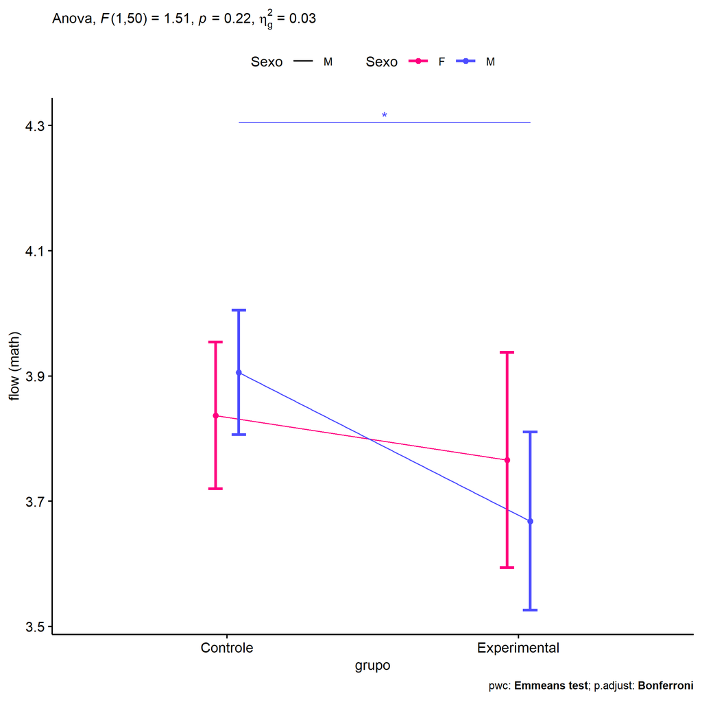

```r
if (length(unique(pdat[["Sexo"]])) >= 2) {
  ggPlotAoC2(pwcs, "grupo", "Sexo", aov, ylab = "flow (math)",
             subtitle = which(aov$Effect == "grupo:Sexo"), addParam = "errorbar") +
    ggplot2::scale_color_manual(values = color[["Sexo"]]) +
    if (ymin.ci < ymax.ci) ggplot2::ylim(ymin.ci, ymax.ci)
}
```

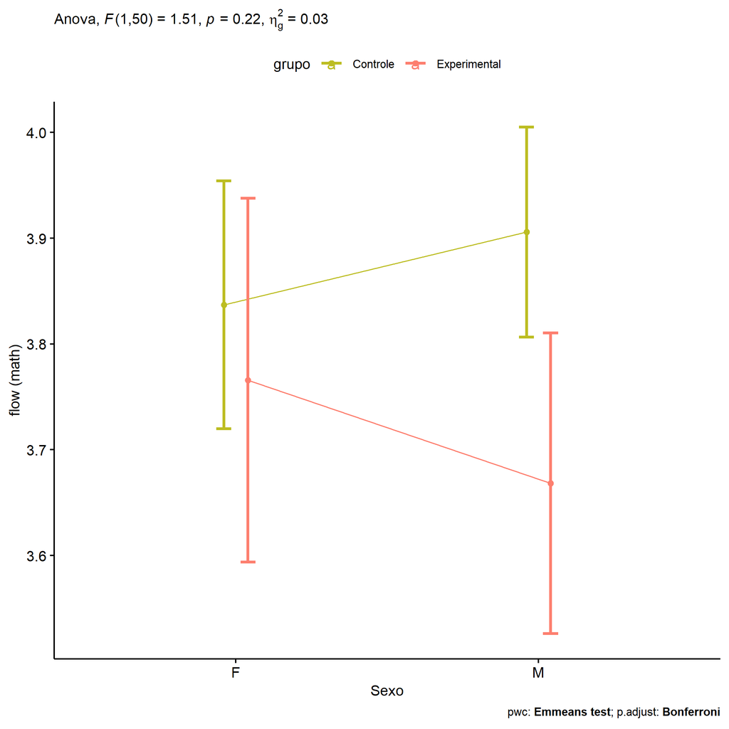

```r
if (length(unique(pdat[["Sexo"]])) >= 2) {
  ggPlotAoC2(pwcs, "Sexo", "grupo", aov, ylab = "flow (math)",
               subtitle = which(aov$Effect == "grupo:Sexo"), addParam = "errorbar") +
      ggplot2::scale_color_manual(values = color[["grupo"]]) +
      if (ymin.ci < ymax.ci) ggplot2::ylim(ymin.ci, ymax.ci)
}
```

```r
if (length(unique(pdat[["Sexo"]])) >= 2) {
  plots <- twoWayAncovaBoxPlots(
    wdat, "fss.media.math", c("grupo","Sexo"), aov, pwcs, covar = "dfs.media.math",
    theme = "classic", color = color[["grupo:Sexo"]],
    subtitle = which(aov$Effect == "grupo:Sexo"))
}
```

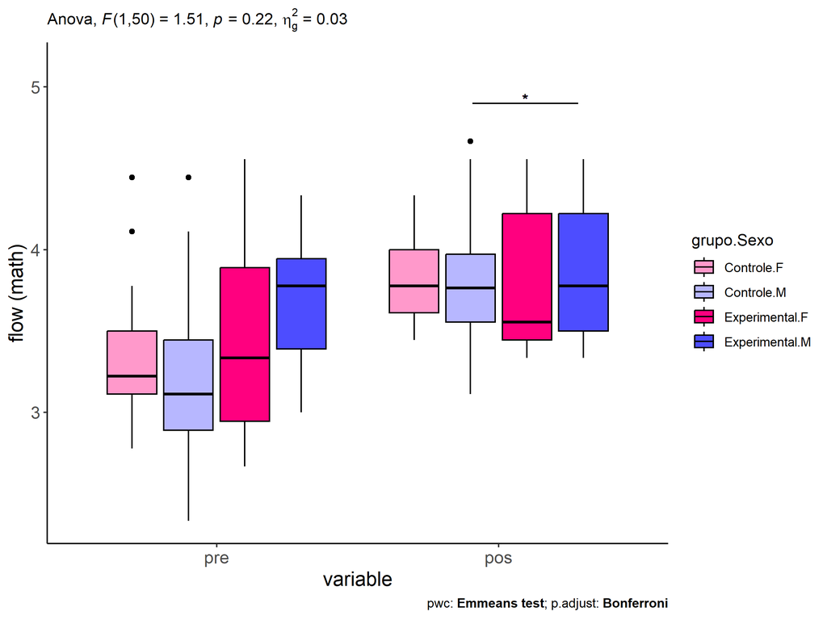

```r
if (length(unique(pdat[["Sexo"]])) >= 2) {
  plots[["grupo:Sexo"]] + ggplot2::ylab("flow (math)") +
  ggplot2::scale_x_discrete(labels=c('pre', 'pos')) +
  if (ymin < ymax) ggplot2::ylim(ymin, ymax)
}
```

```r
if (length(unique(pdat[["Sexo"]])) >= 2) {
  plots <- twoWayAncovaBoxPlots(
    wdat.long, "flow.math", c("grupo","Sexo"), aov, pwc.long,
    pre.post = "time",
    theme = "classic", color = color$prepost)
}
```

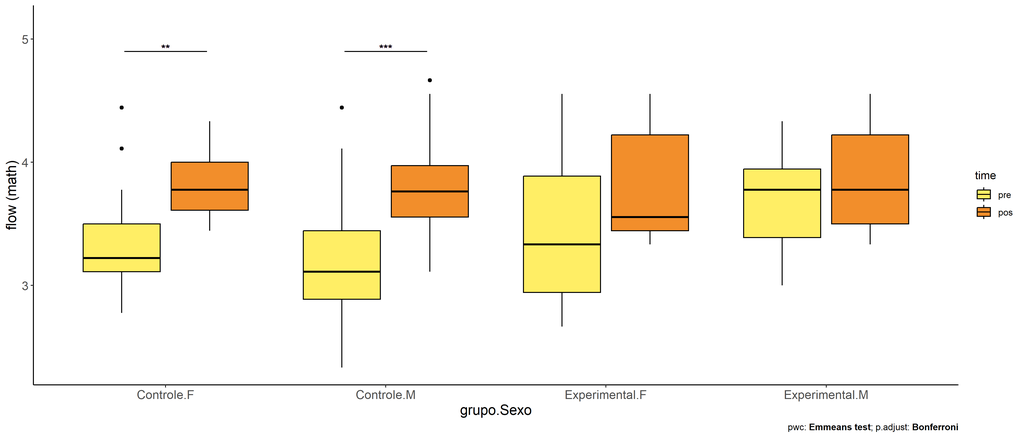

```r
if (length(unique(pdat[["Sexo"]])) >= 2)
  plots[["grupo:Sexo"]] + ggplot2::ylab("flow (math)") +
    if (ymin < ymax) ggplot2::ylim(ymin, ymax)
```

### Checking linearity assumption

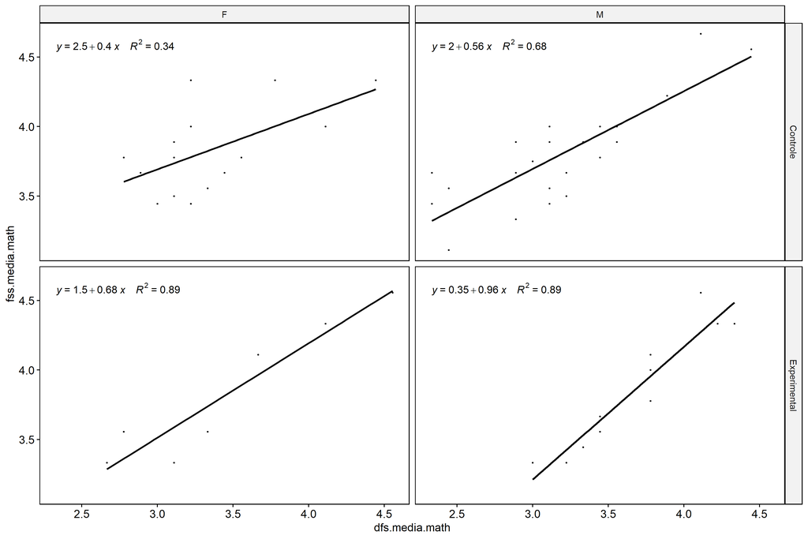

```r
if (length(unique(pdat[["Sexo"]])) >= 2) {
  ggscatter(wdat, x = "dfs.media.math", y = "fss.media.math", size = 0.5,
            facet.by = c("grupo","Sexo"), add = "reg.line")+
    stat_regline_equation(
      aes(label =  paste(..eq.label.., ..rr.label.., sep = "~~~~"))
    ) +
    if (ymin < ymax) ggplot2::ylim(ymin, ymax)
}
```

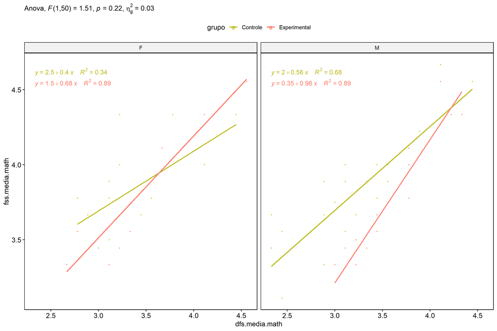

```r
if (length(unique(pdat[["Sexo"]])) >= 2) {
  ggscatter(wdat, x = "dfs.media.math", y = "fss.media.math", size = 0.5,
            color = "grupo", facet.by = "Sexo", add = "reg.line")+
    stat_regline_equation(
      aes(label =  paste(..eq.label.., ..rr.label.., sep = "~~~~"), color = grupo)
    ) +
    ggplot2::labs(subtitle = rstatix::get_test_label(aov, detailed = T, row = which(aov$Effect == "grupo:Sexo"))) +
    ggplot2::scale_color_manual(values = color[["grupo"]]) +
    if (ymin < ymax) ggplot2::ylim(ymin, ymax)
}
```

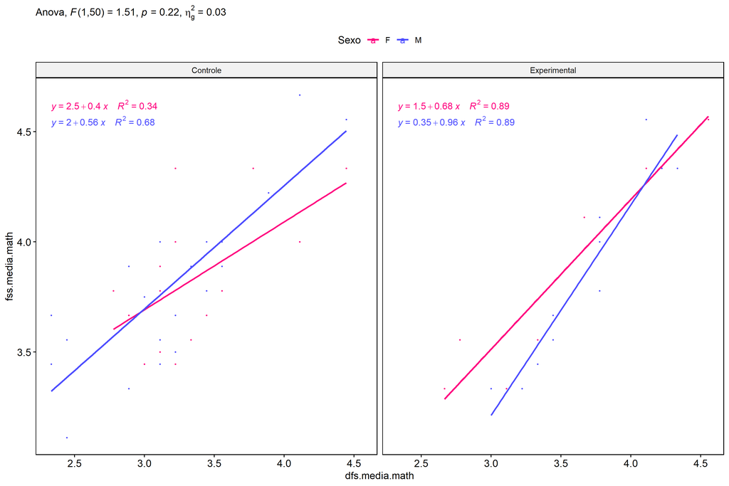

```r
if (length(unique(pdat[["Sexo"]])) >= 2) {
  ggscatter(wdat, x = "dfs.media.math", y = "fss.media.math", size = 0.5,
            color = "Sexo", facet.by = "grupo", add = "reg.line")+
    stat_regline_equation(
      aes(label =  paste(..eq.label.., ..rr.label.., sep = "~~~~"), color = Sexo)
    ) +
    ggplot2::labs(subtitle = rstatix::get_test_label(aov, detailed = T, row = which(aov$Effect == "grupo:Sexo"))) +
    ggplot2::scale_color_manual(values = color[["Sexo"]]) +
    if (ymin < ymax) ggplot2::ylim(ymin, ymax)
}
```

### Checking normality and homogeneity

```r
if (length(unique(pdat[["Sexo"]])) >= 2)
  res <- augment(lm(fss.media.math ~ dfs.media.math + grupo*Sexo, data = wdat))
```

```r
if (length(unique(pdat[["Sexo"]])) >= 2)
  shapiro_test(res$.resid)
```

```
## # A tibble: 1 × 3
##   variable   statistic p.value
##   <chr>          <dbl>   <dbl>
## 1 res$.resid     0.956  0.0421
```

```r
if (length(unique(pdat[["Sexo"]])) >= 2)
  levene_test(res, .resid ~ grupo*Sexo)
```

```
## # A tibble: 1 × 4
##     df1   df2 statistic     p
##   <int> <int>     <dbl> <dbl>
## 1     3    51     0.800 0.500
```

# ANCOVA and Pairwise for two factors **grupo:Zona**

## Without remove non-normal data

```r
pdat = remove_group_data(dat[!is.na(dat[["grupo"]]) & !is.na(dat[["Zona"]]),],
                         "fss.media.math", c("grupo","Zona"))
pdat = pdat[pdat[["Zona"]] %in% do.call(
  intersect, lapply(unique(pdat[["grupo"]]), FUN = function(x) {
    unique(pdat[["Zona"]][which(pdat[["grupo"]] == x)])
  })),]
pdat[["grupo"]] = factor(pdat[["grupo"]], level[["grupo"]])
pdat[["Zona"]] = factor(
  pdat[["Zona"]],
  level[["Zona"]][level[["Zona"]] %in% unique(pdat[["Zona"]])])

pdat.long <- rbind(pdat[,c("id","grupo","Zona")], pdat[,c("id","grupo","Zona")])
pdat.long[["time"]] <- c(rep("pre", nrow(pdat)), rep("pos", nrow(pdat)))
pdat.long[["time"]] <- factor(pdat.long[["time"]], c("pre","pos"))
pdat.long[["flow.math"]] <- c(pdat[["dfs.media.math"]], pdat[["fss.media.math"]])

if (length(unique(pdat[["Zona"]])) >= 2) {
  aov = anova_test(pdat, fss.media.math ~ dfs.media.math + grupo*Zona)
  laov[["grupo:Zona"]] <- get_anova_table(aov)
}
```

```r
if (length(unique(pdat[["Zona"]])) >= 2) {
  pwcs <- list()
  pwcs[["Zona"]] <- emmeans_test(
    group_by(pdat, grupo), fss.media.math ~ Zona,
    covariate = dfs.media.math, p.adjust.method = "bonferroni")
  pwcs[["grupo"]] <- emmeans_test(
    group_by(pdat, Zona), fss.media.math ~ grupo,
    covariate = dfs.media.math, p.adjust.method = "bonferroni")

  pwc <- plyr::rbind.fill(pwcs[["grupo"]], pwcs[["Zona"]])
  pwc <- pwc[,c("grupo","Zona", colnames(pwc)[!colnames(pwc) %in% c("grupo","Zona")])]
}
```

```r
if (length(unique(pdat[["Zona"]])) >= 2) {
  pwc.long <- emmeans_test(dplyr::group_by_at(pdat.long, c("grupo","Zona")),
                           flow.math ~ time,
                           p.adjust.method = "bonferroni")
  lpwc[["grupo:Zona"]] <- plyr::rbind.fill(pwc, pwc.long)
}
```

```r
if (length(unique(pdat[["Zona"]])) >= 2) {
  ds <- get.descriptives(pdat, "fss.media.math", c("grupo","Zona"), covar = "dfs.media.math")
  ds <- merge(ds[ds$variable != "dfs.media.math",],
              ds[ds$variable == "dfs.media.math", !colnames(ds) %in% c("variable")],
              by = c("grupo","Zona"), all.x = T, suffixes = c("", ".dfs.media.math"))
  ds <- merge(get_emmeans(pwcs[["grupo"]]), ds,
              by = c("grupo","Zona"), suffixes = c(".emms", ""))
  ds <- ds[,c("grupo","Zona","n","mean.dfs.media.math","se.dfs.media.math","mean","se",
              "emmean","se.emms","conf.low","conf.high")]

  colnames(ds) <- c("grupo","Zona", "N", paste0(c("M","SE")," (pre)"),
                    paste0(c("M","SE"), " (unadj)"),
                    paste0(c("M", "SE"), " (adj)"), "conf.low", "conf.high")

  lemms[["grupo:Zona"]] <- ds
}
```

## Computing ANCOVA and PairWise After removing non-normal data (OK)

```r
if (length(unique(pdat[["Zona"]])) >= 2) {
  wdat = pdat

  res = residuals(lm(fss.media.math ~ dfs.media.math + grupo*Zona, data = wdat))
  non.normal = getNonNormal(res, wdat$id, plimit = 0.05)

  wdat = wdat[!wdat$id %in% non.normal,]

  wdat.long <- rbind(wdat[,c("id","grupo","Zona")], wdat[,c("id","grupo","Zona")])
  wdat.long[["time"]] <- c(rep("pre", nrow(wdat)), rep("pos", nrow(wdat)))
  wdat.long[["time"]] <- factor(wdat.long[["time"]], c("pre","pos"))
  wdat.long[["flow.math"]] <- c(wdat[["dfs.media.math"]], wdat[["fss.media.math"]])


  ldat[["grupo:Zona"]] = wdat

  (non.normal)
}
```

[output not shown]

```r
if (length(unique(pdat[["Zona"]])) >= 2) {
  aov = anova_test(wdat, fss.media.math ~ dfs.media.math + grupo*Zona)
  laov[["grupo:Zona"]] <- merge(get_anova_table(aov), laov[["grupo:Zona"]],
                                         by="Effect", suffixes = c("","'"))
  df = get_anova_table(aov)
}
```

| Effect | DFn | DFd | F | p | p<.05 | ges |
| --- | --- | --- | --- | --- | --- | --- |
| dfs.media.math | 1 | 103 | 29.791 | 0.000 | * | 0.224 |
| grupo | 1 | 103 | 2.673 | 0.105 |  | 0.025 |
| Zona | 1 | 103 | 3.051 | 0.084 |  | 0.029 |
| grupo:Zona | 1 | 103 | 0.024 | 0.878 |  | 0.000 |

```r
if (length(unique(pdat[["Zona"]])) >= 2) {
  pwcs <- list()
  pwcs[["Zona"]] <- emmeans_test(
    group_by(wdat, grupo), fss.media.math ~ Zona,
    covariate = dfs.media.math, p.adjust.method = "bonferroni")
  pwcs[["grupo"]] <- emmeans_test(
    group_by(wdat, Zona), fss.media.math ~ grupo,
    covariate = dfs.media.math, p.adjust.method = "bonferroni")

  pwc <- plyr::rbind.fill(pwcs[["grupo"]], pwcs[["Zona"]])
  pwc <- pwc[,c("grupo","Zona", colnames(pwc)[!colnames(pwc) %in% c("grupo","Zona")])]
}
```

| grupo | Zona | term | .y. | group1 | group2 | df | statistic | p | p.adj | p.adj.signif |
| --- | --- | --- | --- | --- | --- | --- | --- | --- | --- | --- |
|  | Rural | dfs.media.math*grupo | fss.media.math | Controle | Experimental | 103 | 1.364 | 0.175 | 0.175 | ns |
|  | Urbana | dfs.media.math*grupo | fss.media.math | Controle | Experimental | 103 | 0.899 | 0.371 | 0.371 | ns |
| Controle |  | dfs.media.math*Zona | fss.media.math | Rural | Urbana | 103 | -1.537 | 0.127 | 0.127 | ns |
| Experimental |  | dfs.media.math*Zona | fss.media.math | Rural | Urbana | 103 | -0.856 | 0.394 | 0.394 | ns |

```r
if (length(unique(pdat[["Zona"]])) >= 2) {
  pwc.long <- emmeans_test(dplyr::group_by_at(wdat.long, c("grupo","Zona")),
                           flow.math ~ time,
                           p.adjust.method = "bonferroni")
  lpwc[["grupo:Zona"]] <- merge(plyr::rbind.fill(pwc, pwc.long),
                                         lpwc[["grupo:Zona"]],
                                         by=c("grupo","Zona","term",".y.","group1","group2"),
                                         suffixes = c("","'"))
}
```

| grupo | Zona | term | .y. | group1 | group2 | df | statistic | p | p.adj | p.adj.signif |
| --- | --- | --- | --- | --- | --- | --- | --- | --- | --- | --- |
| Controle | Rural | time | flow.math | pre | pos | 208 | -1.169 | 0.244 | 0.244 | ns |
| Controle | Urbana | time | flow.math | pre | pos | 208 | -1.943 | 0.053 | 0.053 | ns |
| Experimental | Rural | time | flow.math | pre | pos | 208 | 0.525 | 0.600 | 0.600 | ns |
| Experimental | Urbana | time | flow.math | pre | pos | 208 | -1.250 | 0.213 | 0.213 | ns |

```r
if (length(unique(pdat[["Zona"]])) >= 2) {
  ds <- get.descriptives(wdat, "fss.media.math", c("grupo","Zona"), covar = "dfs.media.math")
  ds <- merge(ds[ds$variable != "dfs.media.math",],
              ds[ds$variable == "dfs.media.math", !colnames(ds) %in% c("variable")],
              by = c("grupo","Zona"), all.x = T, suffixes = c("", ".dfs.media.math"))
  ds <- merge(get_emmeans(pwcs[["grupo"]]), ds,
              by = c("grupo","Zona"), suffixes = c(".emms", ""))
  ds <- ds[,c("grupo","Zona","n","mean.dfs.media.math","se.dfs.media.math",
              "mean","se","emmean","se.emms","conf.low","conf.high")]

  colnames(ds) <- c("grupo","Zona", "N", paste0(c("M","SE")," (pre)"),
                    paste0(c("M","SE"), " (unadj)"),
                    paste0(c("M", "SE"), " (adj)"), "conf.low", "conf.high")

  lemms[["grupo:Zona"]] <- merge(ds, lemms[["grupo:Zona"]],
                                          by=c("grupo","Zona"), suffixes = c("","'"))
}
```

| grupo | Zona | N | M (pre) | SE (pre) | M (unadj) | SE (unadj) | M (adj) | SE (adj) | conf.low | conf.high |
| --- | --- | --- | --- | --- | --- | --- | --- | --- | --- | --- |
| Controle | Rural | 54 | 3.274 | 0.075 | 3.406 | 0.072 | 3.396 | 0.074 | 3.249 | 3.543 |
| Controle | Urbana | 17 | 3.222 | 0.116 | 3.611 | 0.182 | 3.629 | 0.132 | 3.367 | 3.891 |
| Experimental | Rural | 29 | 3.360 | 0.097 | 3.280 | 0.121 | 3.224 | 0.102 | 3.022 | 3.426 |
| Experimental | Urbana | 8 | 2.819 | 0.259 | 3.184 | 0.260 | 3.416 | 0.197 | 3.024 | 3.807 |

### Plots for ancova

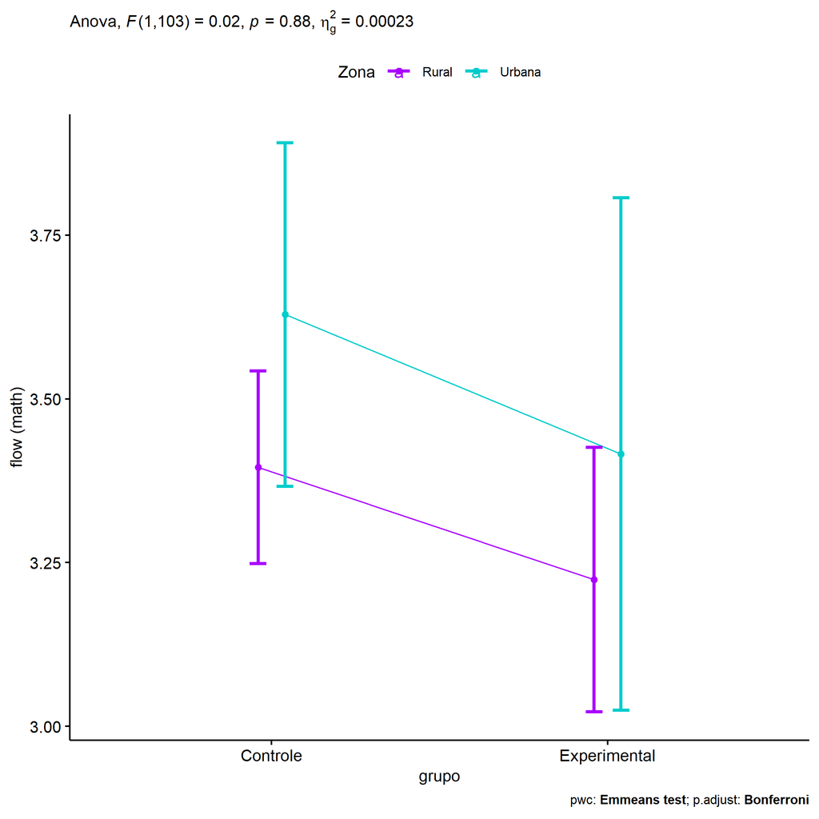

```r
if (length(unique(pdat[["Zona"]])) >= 2) {
  ggPlotAoC2(pwcs, "grupo", "Zona", aov, ylab = "flow (math)",
             subtitle = which(aov$Effect == "grupo:Zona"), addParam = "errorbar") +
    ggplot2::scale_color_manual(values = color[["Zona"]]) +
    if (ymin.ci < ymax.ci) ggplot2::ylim(ymin.ci, ymax.ci)
}
```

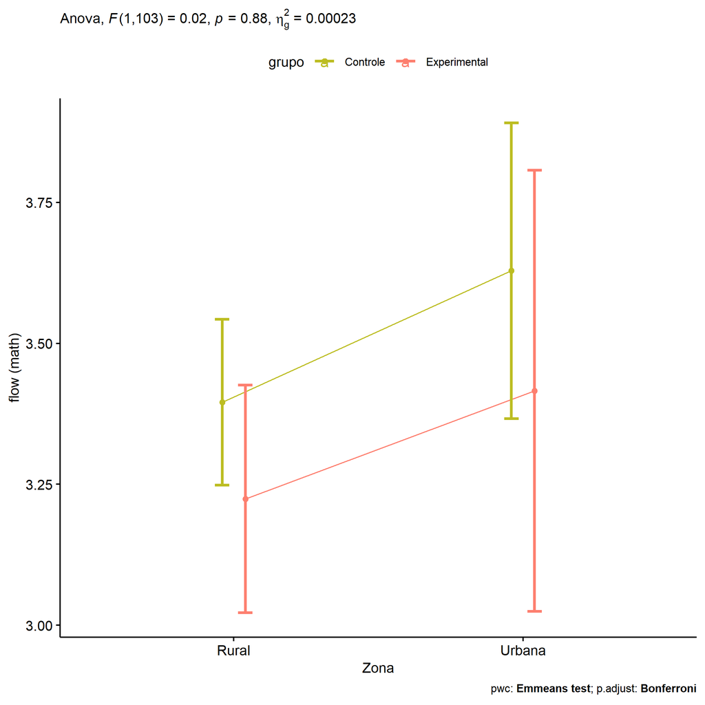

```r
if (length(unique(pdat[["Zona"]])) >= 2) {
  ggPlotAoC2(pwcs, "Zona", "grupo", aov, ylab = "flow (math)",
               subtitle = which(aov$Effect == "grupo:Zona"), addParam = "errorbar") +
      ggplot2::scale_color_manual(values = color[["grupo"]]) +
      if (ymin.ci < ymax.ci) ggplot2::ylim(ymin.ci, ymax.ci)
}
```

```r
if (length(unique(pdat[["Zona"]])) >= 2) {
  plots <- twoWayAncovaBoxPlots(
    wdat, "fss.media.math", c("grupo","Zona"), aov, pwcs, covar = "dfs.media.math",
    theme = "classic", color = color[["grupo:Zona"]],
    subtitle = which(aov$Effect == "grupo:Zona"))
}
```

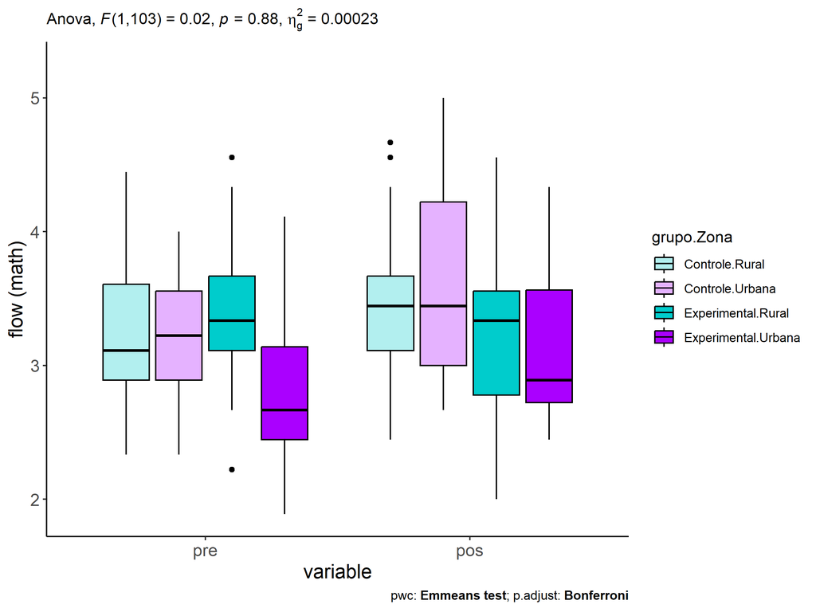

```r
if (length(unique(pdat[["Zona"]])) >= 2) {
  plots[["grupo:Zona"]] + ggplot2::ylab("flow (math)") +
  ggplot2::scale_x_discrete(labels=c('pre', 'pos')) +
  if (ymin < ymax) ggplot2::ylim(ymin, ymax)
}
```

```r
if (length(unique(pdat[["Zona"]])) >= 2) {
  plots <- twoWayAncovaBoxPlots(
    wdat.long, "flow.math", c("grupo","Zona"), aov, pwc.long,
    pre.post = "time",
    theme = "classic", color = color$prepost)
}
```

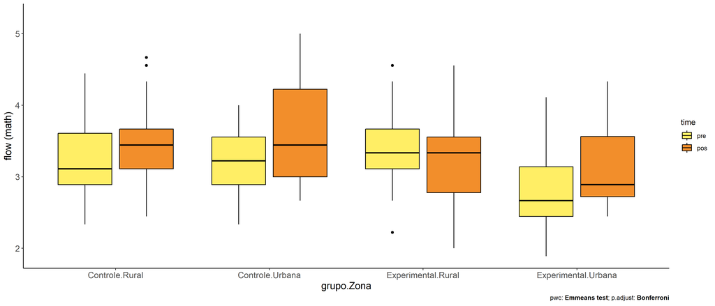

```r
if (length(unique(pdat[["Zona"]])) >= 2)
  plots[["grupo:Zona"]] + ggplot2::ylab("flow (math)") +
    if (ymin < ymax) ggplot2::ylim(ymin, ymax)
```

### Checking linearity assumption

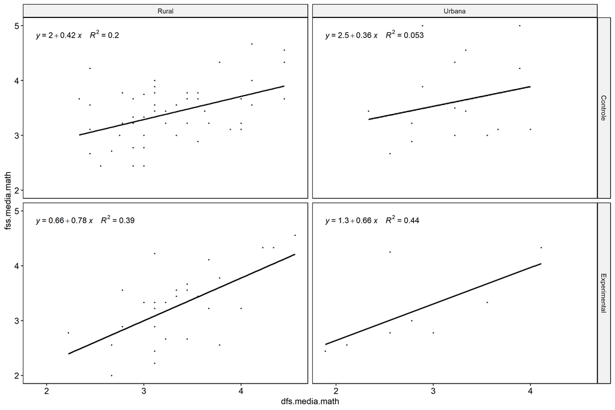

```r
if (length(unique(pdat[["Zona"]])) >= 2) {
  ggscatter(wdat, x = "dfs.media.math", y = "fss.media.math", size = 0.5,
            facet.by = c("grupo","Zona"), add = "reg.line")+
    stat_regline_equation(
      aes(label =  paste(..eq.label.., ..rr.label.., sep = "~~~~"))
    ) +
    if (ymin < ymax) ggplot2::ylim(ymin, ymax)
}
```

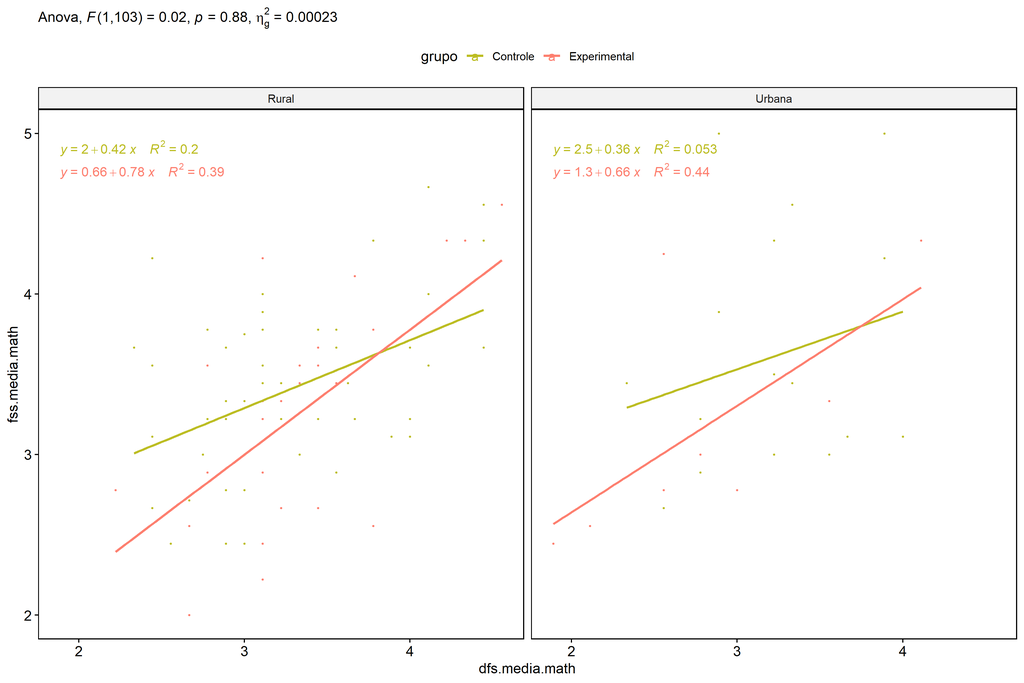

```r
if (length(unique(pdat[["Zona"]])) >= 2) {
  ggscatter(wdat, x = "dfs.media.math", y = "fss.media.math", size = 0.5,
            color = "grupo", facet.by = "Zona", add = "reg.line")+
    stat_regline_equation(
      aes(label =  paste(..eq.label.., ..rr.label.., sep = "~~~~"), color = grupo)
    ) +
    ggplot2::labs(subtitle = rstatix::get_test_label(aov, detailed = T, row = which(aov$Effect == "grupo:Zona"))) +
    ggplot2::scale_color_manual(values = color[["grupo"]]) +
    if (ymin < ymax) ggplot2::ylim(ymin, ymax)
}
```

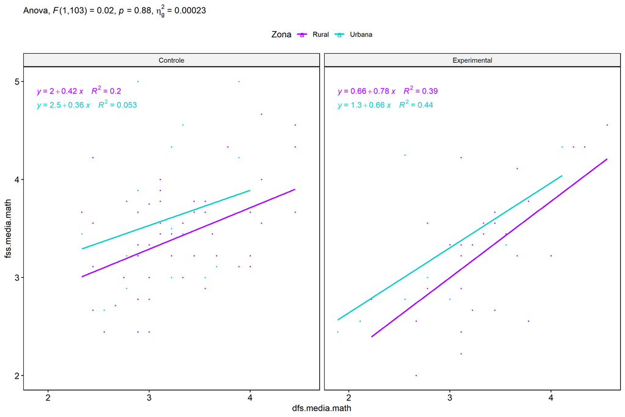

```r
if (length(unique(pdat[["Zona"]])) >= 2) {
  ggscatter(wdat, x = "dfs.media.math", y = "fss.media.math", size = 0.5,
            color = "Zona", facet.by = "grupo", add = "reg.line")+
    stat_regline_equation(
      aes(label =  paste(..eq.label.., ..rr.label.., sep = "~~~~"), color = Zona)
    ) +
    ggplot2::labs(subtitle = rstatix::get_test_label(aov, detailed = T, row = which(aov$Effect == "grupo:Zona"))) +
    ggplot2::scale_color_manual(values = color[["Zona"]]) +
    if (ymin < ymax) ggplot2::ylim(ymin, ymax)
}
```

### Checking normality and homogeneity

```r
if (length(unique(pdat[["Zona"]])) >= 2)
  res <- augment(lm(fss.media.math ~ dfs.media.math + grupo*Zona, data = wdat))
```

```r
if (length(unique(pdat[["Zona"]])) >= 2)
  shapiro_test(res$.resid)
```

```
## # A tibble: 1 × 3
##   variable   statistic p.value
##   <chr>          <dbl>   <dbl>
## 1 res$.resid     0.980  0.0971
```

```r
if (length(unique(pdat[["Zona"]])) >= 2)
  levene_test(res, .resid ~ grupo*Zona)
```

```
## # A tibble: 1 × 4
##     df1   df2 statistic     p
##   <int> <int>     <dbl> <dbl>
## 1     3   104      1.83 0.146
```